# Gapminder Explorer

## Overview

#### *Exploring individual variables*

#### *Exploring various plot types*

## Bringing in data

First lets begin by loading the gapminder dataset and the tidyverse package. Both must first be installed in the console using the `install.packages("")` function.

Now the packages can be primed using the `library()` function for both `gapminder` and `tidyverse`

```r
library(gapminder)
library(tidyverse)
```

## Smell testing data

### Structure of the gapminder object

The `str()` command can tell us about the structure of the gapminder object:

```r
str(gapminder)
```

```
## Classes 'tbl_df', 'tbl' and 'data.frame':    1704 obs. of  6 variables:
##  $ country  : Factor w/ 142 levels "Afghanistan",..: 1 1 1 1 1 1 1 1 1 1 ...
##  $ continent: Factor w/ 5 levels "Africa","Americas",..: 3 3 3 3 3 3 3 3 3 3 ...
##  $ year     : int  1952 1957 1962 1967 1972 1977 1982 1987 1992 1997 ...
##  $ lifeExp  : num  28.8 30.3 32 34 36.1 ...
##  $ pop      : int  8425333 9240934 10267083 11537966 13079460 14880372 12881816 13867957 16317921 22227415 ...
##  $ gdpPercap: num  779 821 853 836 740 ...
```

##### Object

- A general look at the output shows us several variables and the first few values for each observation
- This tells us this is 2-dimensional data with different variable types making this dataset a dataframe object

##### Class

- The output defines class of this dataset in the first line as a: tibble_dataframe, tibble and data.frame

##### Number of variables/columns

- There are 6 variables, meaning there are 6 columns

##### Number of observations/rows

- There are 1704 observations, meaning there are 1704 rows

##### Data type of each variable

- Country and continent variables are of the type factor
- Year and population are of the type integer
- Life expectancy is of the type numerical

### Summary of the gapminder object

Alternatively, the `summary()` method can perform some simple data transformations and provide us with a 6-digit summary for numerical variables (integer, numerical) or counts for categorical variables (factor). This would be more useful to get a simple look at the distribution of each variable.

```r
summary(gapminder)
```

```
##         country        continent        year         lifeExp
##  Afghanistan:  12   Africa  :624   Min.   :1952   Min.   :23.60
##  Albania    :  12   Americas:300   1st Qu.:1966   1st Qu.:48.20
##  Algeria    :  12   Asia    :396   Median :1980   Median :60.71
##  Angola     :  12   Europe  :360   Mean   :1980   Mean   :59.47
##  Argentina  :  12   Oceania : 24   3rd Qu.:1993   3rd Qu.:70.85
##  Australia  :  12                  Max.   :2007   Max.   :82.60
##  (Other)    :1632
##       pop              gdpPercap
##  Min.   :6.001e+04   Min.   :   241.2
##  1st Qu.:2.794e+06   1st Qu.:  1202.1
##  Median :7.024e+06   Median :  3531.8
##  Mean   :2.960e+07   Mean   :  7215.3
##  3rd Qu.:1.959e+07   3rd Qu.:  9325.5
##  Max.   :1.319e+09   Max.   :113523.1
##
```

## Exploring individual variable

#### Categorical variable: continent

First, select the categorical variable, “continent”, and store in the value “c”. Then use the `summary()` method to retrieve a summary of this variable. We can see there are 5 continents here: Africa, Americas, Asia, Europe and Oceania. The number of obserations with each continent are tallied alongside.

```r
#first select all observations of the continent variable and place in the value 'c'

c <- select(gapminder, continent)

#use the summary() method to retrieve desired statistics

summary(c)
```

```
##     continent
##  Africa  :624
##  Americas:300
##  Asia    :396
##  Europe  :360
##  Oceania : 24
```

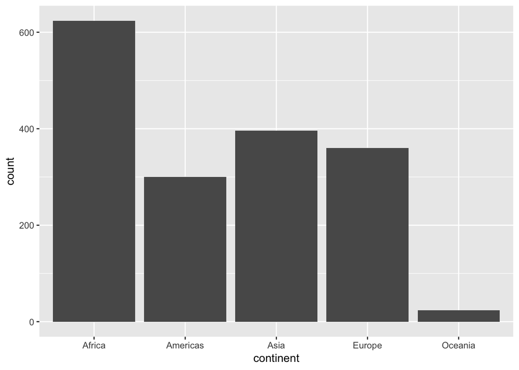

```r
#next lets plot a bar graph of the counts of each continent

ggplot(c) + geom_bar(mapping=aes(x=continent))
```

#### Numerical variable: life expectancy

```r
#place lifeExp variable of gapminder in "p", along with continent and year for further analysis

p <- select(gapminder, lifeExp,continent,year) %>% filter(year == 2007)

#summarize 'p' with 6-digit summary

summary(p)
```

```
##     lifeExp         continent       year
##  Min.   :39.61   Africa  :52   Min.   :2007
##  1st Qu.:57.16   Americas:25   1st Qu.:2007
##  Median :71.94   Asia    :33   Median :2007
##  Mean   :67.01   Europe  :30   Mean   :2007
##  3rd Qu.:76.41   Oceania : 2   3rd Qu.:2007
##  Max.   :82.60                 Max.   :2007
```

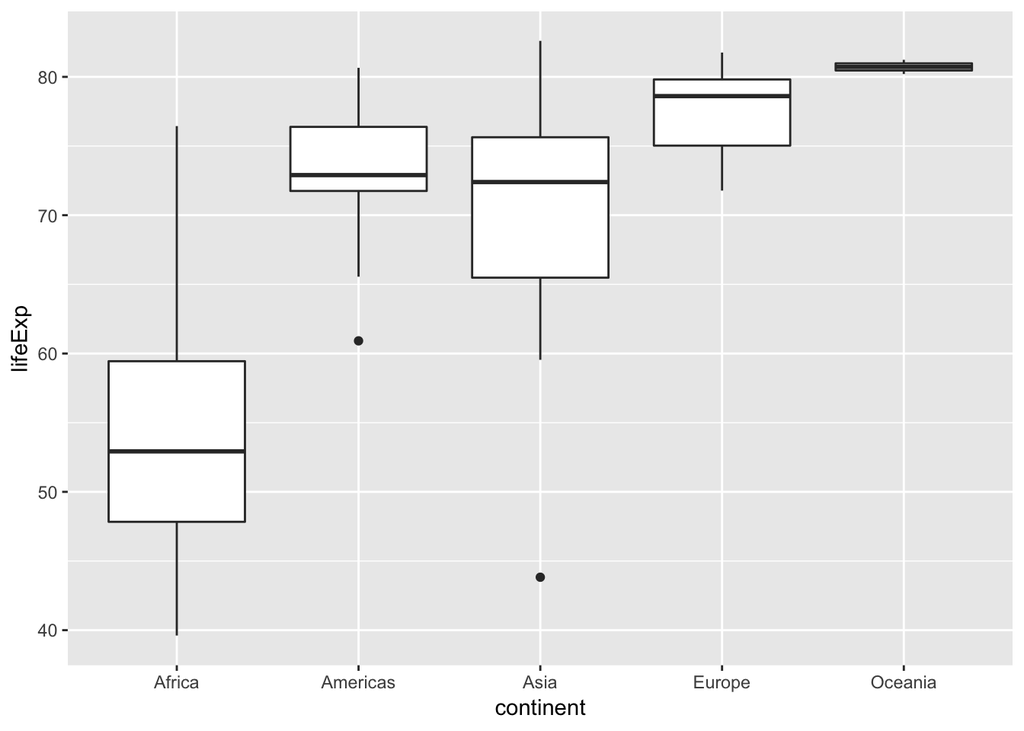

```r
#next lets look at the distribution of the population variable

ggplot(p) + geom_boxplot(mapping=aes(x=continent, y = lifeExp))
```